[figure not shown]

This page is part of the documentation for the [Machine Learning Database](http://mldb.ai).

It is a static snapshot of a Notebook which you can play with interactively by trying MLDB online now.  
It's free and takes 30 seconds to get going.

# Procedures and Functions Tutorial

MLDB is the Machine Learning Database, and all machine learning operations are done via Procedures and Functions. Training a model happens via Procedures, and applying a model happens via Functions.

The notebook cells below use `pymldb`'s `Connection` class to make REST API calls. You can check out the Using `pymldb` Tutorial for more details.

```python
from pymldb import Connection
mldb = Connection("http://localhost")
```

## Loading a Dataset

The classic [Iris Flower Dataset](http://en.wikipedia.org/wiki/Iris_flower_data_set) isn't very big but it's well-known and easy to reason about so it's a good example dataset to use for machine learning examples.

We can import it directly from a remote URL:

```python
mldb.put('/v1/procedures/import_iris', {
    "type": "import.text",
    "params": {
        "dataFileUrl": "http://public.mldb.ai/iris.data",
        "headers": [ "sepal length", "sepal width", "petal length", "petal width", "class" ],
        "outputDataset": "iris",
        "runOnCreation": True
    }
})
```

**PUT http://localhost/v1/procedures/import_iris**  
**201 Created**

[output not shown]

## A quick look at the data

We can use the Query API to get the data into a Pandas DataFrame to take a quick look at it.

```python
df = mldb.query("select * from iris")
df.head()
```

| _rowName | sepal length | sepal width | petal length | petal width | class |
| --- | --- | --- | --- | --- | --- |
| 97 | 5.7 | 2.9 | 4.2 | 1.3 | Iris-versicolor |
| 11 | 5.4 | 3.7 | 1.5 | 0.2 | Iris-setosa |
| 112 | 6.4 | 2.7 | 5.3 | 1.9 | Iris-virginica |
| 134 | 6.3 | 2.8 | 5.1 | 1.5 | Iris-virginica |
| 142 | 6.9 | 3.1 | 5.1 | 2.3 | Iris-virginica |

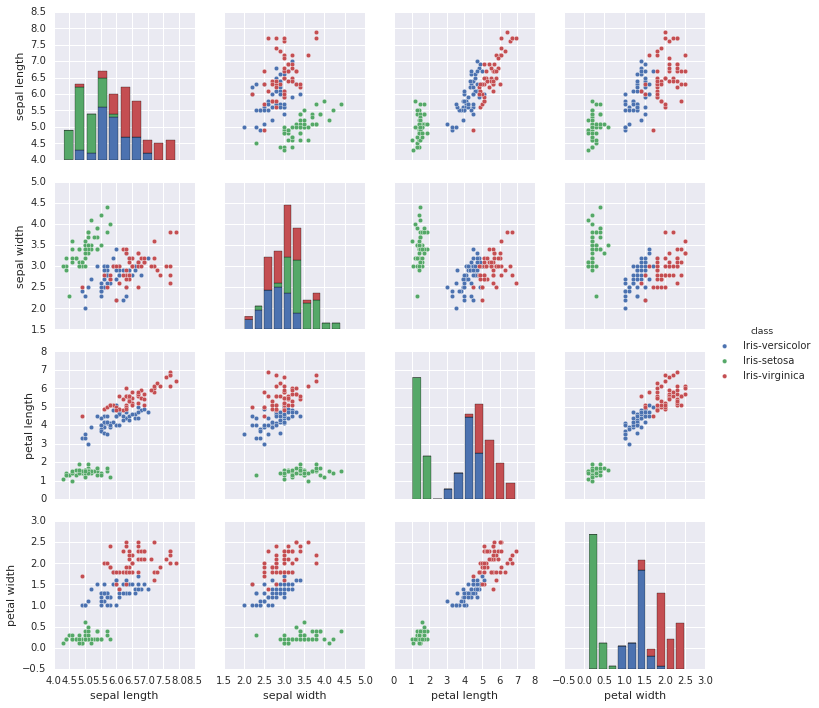

```python
%matplotlib inline
import seaborn as sns, pandas as pd

sns.pairplot(df, hue="class", size=2.5)
```

## Unsupervised Machine Learning with a `kmeans.train` Procedure

We will create and run a Procedure of type `kmeans.train`. This will train an unsupervised K-Means model and use it to assign each row in the input to a cluster, in the output dataset.

```python
mldb.put('/v1/procedures/iris_train_kmeans', {
    'type' : 'kmeans.train',
    'params' : {
        'trainingData' : 'select * EXCLUDING(class) from iris',
        'outputDataset' : 'iris_clusters',
        'numClusters' : 3,
        'metric': 'euclidean',
        "runOnCreation": True
    }
})
```

**PUT http://localhost/v1/procedures/iris_train_kmeans**  
**201 Created**

```
{
  "status": {
    "firstRun": {
      "runStarted": "2016-03-22T16:20:18.0258212Z",
      "runFinished": "2016-03-22T16:20:18.030994Z",
      "id": "2016-03-22T16:20:18.025736Z-5bc7042b732cb41f",
      "state": "finished"
    }
  },
  "config": {
    "params": {
      "trainingData": "select * EXCLUDING(class) from iris",
      "metric": "euclidean",
      "outputDataset": "iris_clusters",
      "numClusters": 3,
      "runOnCreation": true
    },
    "type": "kmeans.train",
    "id": "iris_train_kmeans"
  },
  "state": "ok",
  "type": "kmeans.train",
  "id": "iris_train_kmeans"
}
```

Now we can look at the output dataset and compare the clusters the model learned with the three types of flower in the dataset.

```python
mldb.query("""
    select pivot(class, num) as *
    from (
        select cluster, class, count(*) as num
        from merge(iris_clusters, iris)
        group by cluster, class
    )
    group by cluster
""")
```

| _rowName | Iris-setosa | Iris-versicolor | Iris-virginica |
| --- | --- | --- | --- |
| [0] | 50 | NaN | NaN |
| [1] | NaN | 2 | 36 |
| [2] | NaN | 48 | 14 |

As you can see, the K-means algorithm doesn't do a great job of clustering this data (as is mentioned in the Wikipedia article!).

## Supervised Machine Learning with `classifier.train` and `.test` Procedures

We will now create and run a Procedure of type `classifier.train`. The configuration below will use 20% of the data to train a decision tree to classify rows into the three classes of Iris. The output of this procedure is a Function, which we will be able to call from REST or SQL.

```python
mldb.put('/v1/procedures/iris_train_classifier', {
    'type' : 'classifier.train',
    'params' : {
        'trainingData' : """
            select
                {* EXCLUDING(class)} as features,
                class as label
            from iris
            where rowHash() % 5 = 0
        """,
        "algorithm": "dt",
        "modelFileUrl": "file://models/iris.cls",
        "mode": "categorical",
        "functionName": "iris_classify",
        "runOnCreation": True
    }
})
```

**PUT http://localhost/v1/procedures/iris_train_classifier**  
**201 Created**

```
{
  "status": {
    "firstRun": {
      "runStarted": "2016-03-22T16:20:18.0753982Z",
      "runFinished": "2016-03-22T16:20:18.0805328Z",
      "id": "2016-03-22T16:20:18.075322Z-5bc7042b732cb41f",
      "state": "finished"
    }
  },
  "config": {
    "params": {
      "functionName": "iris_classify",
      "trainingData": "\n            select \n                {* EXCLUDING(class)} as features, \n                class as label \n            from iris \n            where rowHash() % 5 = 0\n        ",
      "modelFileUrl": "file://models/iris.cls",
      "runOnCreation": true,
      "mode": "categorical",
      "algorithm": "dt"
    },
    "type": "classifier.train",
    "id": "iris_train_classifier"
  },
  "state": "ok",
  "type": "classifier.train",
  "id": "iris_train_classifier"
}
```

We can now test the classifier we just trained on the subset of the data we didn't use for training. To do so we use a procedure of type `classifier.test`.

```python
rez = mldb.put('/v1/procedures/iris_test_classifier', {
    'type' : 'classifier.test',
    'params' : {
        'testingData' : """
            select
                iris_classify({
                    features: {* EXCLUDING(class)}
                }) as score,
                class as label
            from iris
            where rowHash() % 5 != 0
        """,
        "mode": "categorical",
        "runOnCreation": True
    }
})

runResults = rez.json()["status"]["firstRun"]["status"]
print rez
```

```
<Response [201]>
```

The procedure returns a confusion matrix, which you can compare with the one that resulted from the K-means procedure.

```python
pd.DataFrame(runResults["confusionMatrix"])\
    .pivot_table(index="actual", columns="predicted", fill_value=0)
```

| predicted actual | count Iris-setosa | count Iris-versicolor | count Iris-virginica |
| --- | --- | --- | --- |
| Iris-setosa | 40 | 0 | 0 |
| Iris-versicolor | 0 | 37 | 2 |
| Iris-virginica | 0 | 6 | 38 |

As you can see, the decision tree does a much better job of classifying the data than the K-means model, using 20% of the examples as training data.

The procedure also returns standard classification statistics on how the classifier performed on the test set. Below are performance statistics for each label:

```python
pd.DataFrame.from_dict(runResults["labelStatistics"]).transpose()
```

|  | f | precision | recall | support |
| --- | --- | --- | --- | --- |
| Iris-setosa | 1.000000 | 1.000000 | 1.000000 | 40 |
| Iris-versicolor | 0.902439 | 0.860465 | 0.948718 | 39 |
| Iris-virginica | 0.904762 | 0.950000 | 0.863636 | 44 |

They are also available, averaged over all labels:

```python
pd.DataFrame.from_dict({"weightedStatistics": runResults["weightedStatistics"]})
```

|  | weightedStatistics |
| --- | --- |
| f | 0.934997 |
| precision | 0.937871 |
| recall | 0.934959 |
| support | 123.000000 |

### Scoring new examples

We can call the Function REST API endpoint to classify a never-before-seen set of measurements like this:

```python
mldb.get('/v1/functions/iris_classify/application', input={
    "features":{
        "petal length": 1,
        "petal width": 2,
        "sepal length": 3,
        "sepal width": 4
    }
})
```

**GET http://localhost/v1/functions/iris_classify/application?input=%7B%22features%22%3A+%7B%22sepal+width%22%3A+4%2C+%22petal+width%22%3A+2%2C+%22petal+length%22%3A+1%2C+%22sepal+length%22%3A+3%7D%7D**  
**200 OK**

```
{
  "output": {
    "scores": [
      [
        "\"Iris-setosa\"",
        [
          1,
          "-Inf"
        ]
      ],
      [
        "\"Iris-versicolor\"",
        [
          0,
          "-Inf"
        ]
      ],
      [
        "\"Iris-virginica\"",
        [
          0,
          "-Inf"
        ]
      ]
    ]
  }
}
```

## Where to next?

Check out the other Tutorials and Demos.

You can also take a look at the `classifier.experiment` procedure type that can be used to train and test a classifier in a single call.